# wfkelly2_HW3

William Kelly

6/21/2021

# Load Libraries

```r
library(tidyverse)
```

```r
library(corrplot)
library(Hmisc)
```

# 1) Import store_3HE dataframe as df

```r
df <- read.csv("store_3HE.csv")
```

# 2) Familiarize w/ the features of the data frame

```r
str(df)
```

```
## 'data.frame':    771 obs. of  20 variables:
##  $ store                  : int  105 117 122 123 182 183 186 194 227 233 ...
##  $ city                   : chr  "BROCKVILLE" "BURLINGTON" "BURLINGTON" "BURLINGTON" ...
##  $ region                 : chr  "ONTARIO" "ONTARIO" "ONTARIO" "ONTARIO" ...
##  $ province               : chr  "ON" "ON" "ON" "ON" ...
##  $ size                   : int  496 875 691 763 784 NA 966 710 973 967 ...
##  $ revenue                : chr  "984.7" "2629.32" "2786.73" "2834.49" ...
##  $ units                  : num  470 1131 1229 1258 1950 ...
##  $ cost                   : num  591 1622 1709 1720 2486 ...
##  $ gross_profit           : num  394 1008 1077 1115 1633 ...
##  $ promo_units            : num  210 401 450 477 665 ...
##  $ energy_units           : num  72.1 192.8 240.5 194.2 199.7 ...
##  $ regularBars_units      : num  38.6 75 93.7 99.4 175.5 ...
##  $ gum_units              : num  29.3 55.9 64.3 73.2 145.8 ...
##  $ bagpegCandy_units      : num  13.4 42.1 29.9 54.1 68.1 ...
##  $ isotonics_units        : num  20.7 87.6 105.7 118.2 109.3 ...
##  $ singleServePotato_units: num  18.6 36.4 48 39.7 85.7 ...
##  $ takeHomePotato_units   : num  7.71 33.46 19.9 22.1 42.33 ...
##  $ kingBars_units         : num  17.9 47.4 45.2 45.3 79.8 ...
##  $ flatWater_units        : num  56.5 98.4 130.3 132.8 204.1 ...
##  $ psd591Ml_units         : num  39.7 38.7 47.3 39.9 50.3 ...
```

```r
summary(df)
```

```
##      store           city              region            province
##  Min.   :  105   Length:771         Length:771         Length:771
##  1st Qu.: 6226   Class :character   Class :character   Class :character
##  Median :34438   Mode  :character   Mode  :character   Mode  :character
##  Mean   :34226
##  3rd Qu.:59663
##  Max.   :98788
##
##       size          revenue              units              cost
##  Min.   : 276.0   Length:771         Min.   :  42.65   Min.   :   41.12
##  1st Qu.: 671.8   Class :character   1st Qu.: 911.85   1st Qu.: 1229.12
##  Median : 792.5   Mode  :character   Median :1351.25   Median : 1843.41
##  Mean   : 755.5                      Mean   :1559.78   Mean   : 2180.51
##  3rd Qu.: 893.0                      3rd Qu.:1941.60   3rd Qu.: 2689.76
##  Max.   :1163.0                      Max.   :9715.83   Max.   :14228.89
##  NA's   :15
##   gross_profit       promo_units      energy_units    regularBars_units
##  Min.   :   36.36   Min.   :  17.5   Min.   :   4.1   Min.   :  5.10
##  1st Qu.:  771.74   1st Qu.: 344.4   1st Qu.: 142.7   1st Qu.: 75.67
##  Median : 1150.93   Median : 499.3   Median : 215.6   Median :110.65
##  Mean   : 1388.03   Mean   : 567.0   Mean   : 253.0   Mean   :123.95
##  3rd Qu.: 1702.92   3rd Qu.: 730.5   3rd Qu.: 317.1   3rd Qu.:154.84
##  Max.   :10457.82   Max.   :3116.5   Max.   :1576.3   Max.   :681.56
##
##    gum_units      bagpegCandy_units isotonics_units  singleServePotato_units
##  Min.   :  1.88   Min.   :  0.00    Min.   :  3.98   Min.   :  1.75
##  1st Qu.: 53.49   1st Qu.: 24.43    1st Qu.: 57.79   1st Qu.: 29.51
##  Median : 77.88   Median : 41.65    Median : 84.48   Median : 44.92
##  Mean   : 85.53   Mean   : 50.33    Mean   : 98.76   Mean   : 56.34
##  3rd Qu.:110.11   3rd Qu.: 63.72    3rd Qu.:124.16   3rd Qu.: 67.84
##  Max.   :318.69   Max.   :381.96    Max.   :562.46   Max.   :439.06
##
##  takeHomePotato_units kingBars_units   flatWater_units   psd591Ml_units
##  Min.   :  0.00       Min.   :  0.00   Min.   :  11.96   Min.   :  0.00
##  1st Qu.: 15.69       1st Qu.: 33.89   1st Qu.:  82.33   1st Qu.: 31.28
##  Median : 28.85       Median : 49.87   Median : 128.98   Median : 48.25
##  Mean   : 38.05       Mean   : 58.68   Mean   : 158.03   Mean   : 60.57
##  3rd Qu.: 49.31       3rd Qu.: 73.33   3rd Qu.: 190.32   3rd Qu.: 74.95
##  Max.   :360.19       Max.   :471.19   Max.   :1424.27   Max.   :390.38
##
```

```r
head(df)
```

```
##   store       city  region province size revenue   units    cost gross_profit
## 1   105 BROCKVILLE ONTARIO       ON  496   984.7  470.46  590.73       393.97
## 2   117 BURLINGTON ONTARIO       ON  875 2629.32 1131.38 1621.58      1007.74
## 3   122 BURLINGTON ONTARIO       ON  691 2786.73 1229.46 1709.45      1077.27
## 4   123 BURLINGTON ONTARIO       ON  763 2834.49 1257.63 1719.61      1114.88
## 5   182  DON MILLS ONTARIO       ON  784 4118.36 1949.50 2485.83      1632.53
## 6   183  DON MILLS ONTARIO       ON   NA  374.83  186.54  227.36       147.47
##   promo_units energy_units regularBars_units gum_units bagpegCandy_units
## 1      210.23        72.13             38.63     29.29             13.38
## 2      401.46       192.77             75.04     55.85             42.15
## 3      450.04       240.48             93.73     64.27             29.85
## 4      476.83       194.21             99.44     73.25             54.15
## 5      664.71       199.73            175.48    145.81             68.06
## 6       79.23        34.23             17.06     11.71              3.73
##   isotonics_units singleServePotato_units takeHomePotato_units kingBars_units
## 1           20.69                   18.60                 7.71          17.87
## 2           87.62                   36.44                33.46          47.44
## 3          105.65                   47.96                19.90          45.21
## 4          118.19                   39.67                22.10          45.33
## 5          109.35                   85.71                42.33          79.81
## 6            9.29                    8.48                 0.00          11.88
##   flatWater_units psd591Ml_units
## 1           56.54          39.71
## 2           98.42          38.73
## 3          130.27          47.31
## 4          132.77          39.87
## 5          204.06          50.29
## 6           25.31           2.69
```

```r
tail(df)
```

```
##     store        city region province size revenue   units    cost gross_profit
## 766 94285     UNKNOWN QUEBEC  UNKNOWN  343 1121.61  534.63  678.85       442.75
## 767 95198       SOOKE   WEST       BC  707 2910.59 1305.92 1777.54      1133.05
## 768 95342 MAPLE RIDGE   WEST       BC  711 1786.36  789.38 1088.62       697.74
## 769 95849   VANCOUVER   WEST       BC  444 1497.23  703.52  902.25       594.97
## 770 97250    WINNIPEG   WEST       MB  723 2093.18  928.54 1325.07       768.11
## 771 98788   VANCOUVER   WEST       BC  885 3753.52 1644.13 2245.66      1507.87
##     promo_units energy_units regularBars_units gum_units bagpegCandy_units
## 766      168.93        90.44             43.00     40.19              0.74
## 767      401.46       151.17            122.63     51.46             51.12
## 768      352.19       130.87             70.83     46.50             22.69
## 769      256.42        81.98             66.71     29.29             18.42
## 770      438.96       113.96             72.38     38.17             31.48
## 771      451.71       207.17            118.27     86.92             52.98
##     isotonics_units singleServePotato_units takeHomePotato_units kingBars_units
## 766           34.22                   22.07                 3.15          32.93
## 767           85.21                   46.25                30.15          74.52
## 768           52.69                   19.02                14.58          22.52
## 769           72.29                   24.83                 7.60          26.60
## 770           68.37                   30.00                27.44          38.67
## 771          105.87                   68.38                38.83          47.79
##     flatWater_units psd591Ml_units
## 766           49.00          18.00
## 767          110.79          43.27
## 768           73.54          32.15
## 769           86.15          24.88
## 770           93.10          59.35
## 771          195.31          37.75
```

```r
slice_sample(df)
```

```
##   store         city region province size revenue   units   cost gross_profit
## 1 12845 BOUCHERVILLE QUEBEC       QC  882 2554.14 1126.69 1556.2       997.94
##   promo_units energy_units regularBars_units gum_units bagpegCandy_units
## 1      386.35       244.81             79.85     85.65             32.62
##   isotonics_units singleServePotato_units takeHomePotato_units kingBars_units
## 1           74.83                    48.1                30.96          33.17
##   flatWater_units psd591Ml_units
## 1           84.46          37.02
```

```r
# unique(df)
n_distinct(df)
```

```
## [1] 771
```

From the str function can see that there are 771 rows of data with 20 different columns. Noticed from Summary function the revenue column is in character format. Also can see that there are 15 NA’s in the size column and 1 NA in Revenue col.

# 3) Convert Values in Revenue to numeric data type

```r
df$revenue <- as.numeric(df$revenue)
```

# 4) Delete rows that contain missing values in any column

```r
df <- df %>% filter(size != "NA", revenue != "NA")
```

Noticed 15 NAs in size column and 1 in revenue so filtered out rows w/ NA’s (755 rows)

# 5) Create two dataframes df_low and df_high

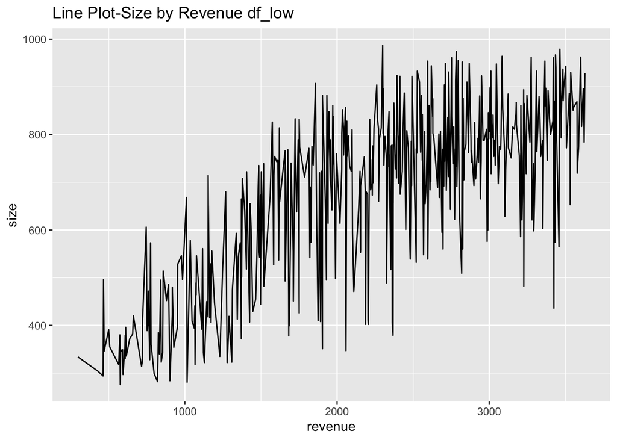

```r
# Calculate mean of revenue from df
df_mean_revenue <- mean(df$revenue)
df_low <- df %>% filter(df$revenue < df_mean_revenue)
df_high <- df %>% filter(df$revenue >= df_mean_revenue)

# Line plots for df_low and df_high showing Revenue by Size
ggplot(df_low,aes(x=revenue,y=size)) +
  geom_line() +
  labs(title='Line Plot-Size by Revenue df_low')
```

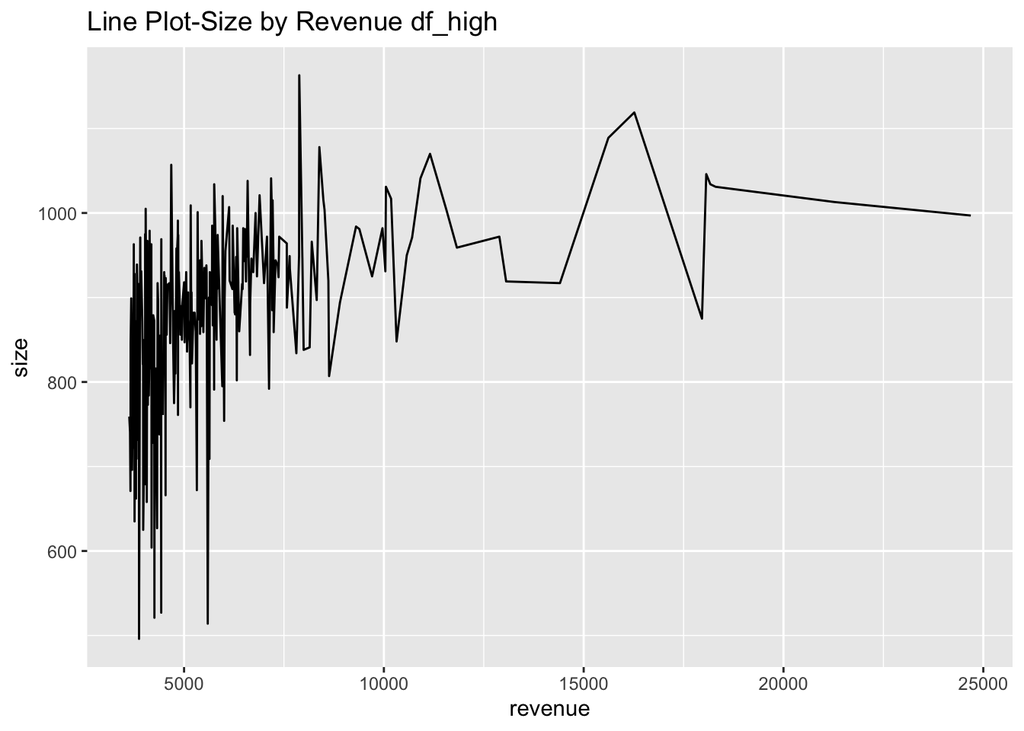

```r
ggplot(df_high,aes(x=revenue,y=size)) +
  geom_line() +
  labs(title='Line Plot-Size by Revenue df_high')
```

One can see by the Line Plot that for both df_low and df_high the Revenue and Size is a positive relationship, as Revenue goes up the size also increases.

# 6) Correlation between Revenue and Size of df

```r
cor(df$revenue,df$size)
```

```
## [1] 0.6175055
```

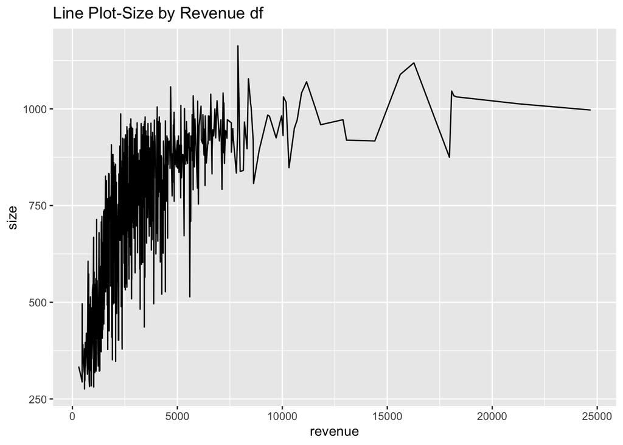

```r
ggplot(df,aes(x=revenue,y=size)) +
  geom_line() +
  labs(title='Line Plot-Size by Revenue df')
```

As shown in the line plot for df dataframe the relationship between Revenue and Size is a positive slope meaning as Revenue increases, Size increases. The Correlation calculated for Revenue and Size is 0.6175055.

# 7) Boxplots of Revenue for each region

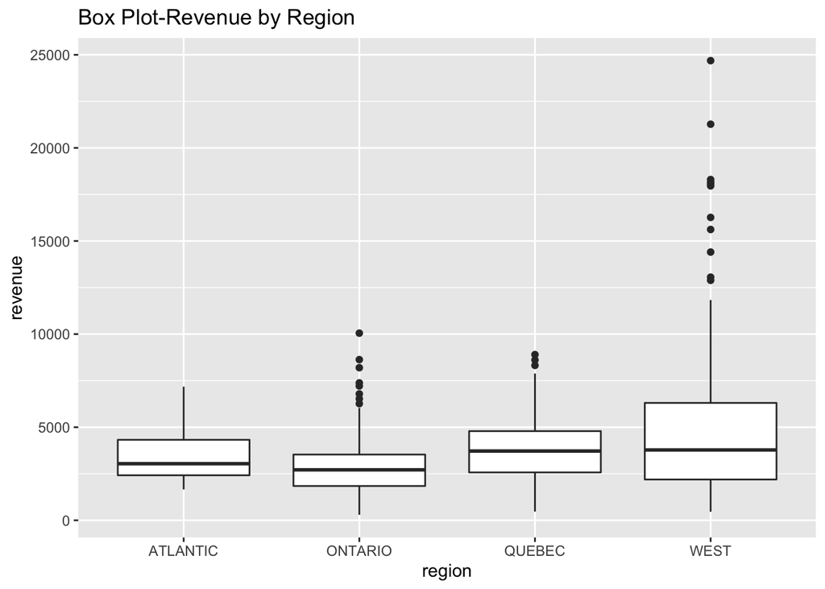

```r
ggplot(df, aes(x=region, y=revenue)) +
  geom_boxplot() +
  labs(title = 'Box Plot-Revenue by Region')
```

# 8) Correlation between revenue and promo_units

```r
cor(df$revenue,df$promo_units)
```

```
## [1] 0.9659697
```

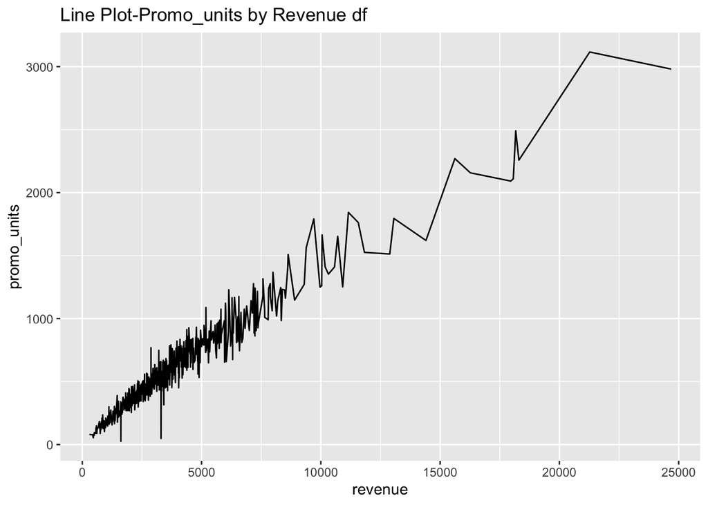

```r
ggplot(df,aes(x=revenue,y=promo_units)) +
  geom_line() +
  labs(title='Line Plot-Promo_units by Revenue df')
```

Correlation between revenue and promo_units is 0.9659697 This aligns with expectation in that more promo units result in higher revenue. Based on the Line Plot trend I believe that selling more units on promotion will increase revenue due to the positive slope/correlation b/t the two variables.

# 9) Bar Chart showing total gross_profit for each province

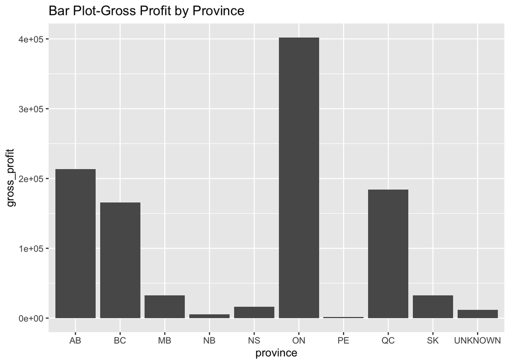

```r
ggplot(df, aes(x=province, y=gross_profit)) +
  geom_col() +
  labs(title = 'Bar Plot-Gross Profit by Province')
```

From the Bar Plot we can see that the provinces ON, AB and QC have the highest gross profit. While the provinces NB, PE, and Unknown are the lowest in gross profit.

# 10) Correlation Matrix b/t Average Store Sales for all Product Categories

```r
Product_Categories <- df[,c(10,11,12,13,14,15,16,17,18,19,20)]
head(Product_Categories)
```

```
##   promo_units energy_units regularBars_units gum_units bagpegCandy_units
## 1      210.23        72.13             38.63     29.29             13.38
## 2      401.46       192.77             75.04     55.85             42.15
## 3      450.04       240.48             93.73     64.27             29.85
## 4      476.83       194.21             99.44     73.25             54.15
## 5      664.71       199.73            175.48    145.81             68.06
## 6     1143.33       419.19            271.58    212.42            153.90
##   isotonics_units singleServePotato_units takeHomePotato_units kingBars_units
## 1           20.69                   18.60                 7.71          17.87
## 2           87.62                   36.44                33.46          47.44
## 3          105.65                   47.96                19.90          45.21
## 4          118.19                   39.67                22.10          45.33
## 5          109.35                   85.71                42.33          79.81
## 6          166.37                  130.79               136.79         114.50
##   flatWater_units psd591Ml_units
## 1           56.54          39.71
## 2           98.42          38.73
## 3          130.27          47.31
## 4          132.77          39.87
## 5          204.06          50.29
## 6          328.63         112.38
```

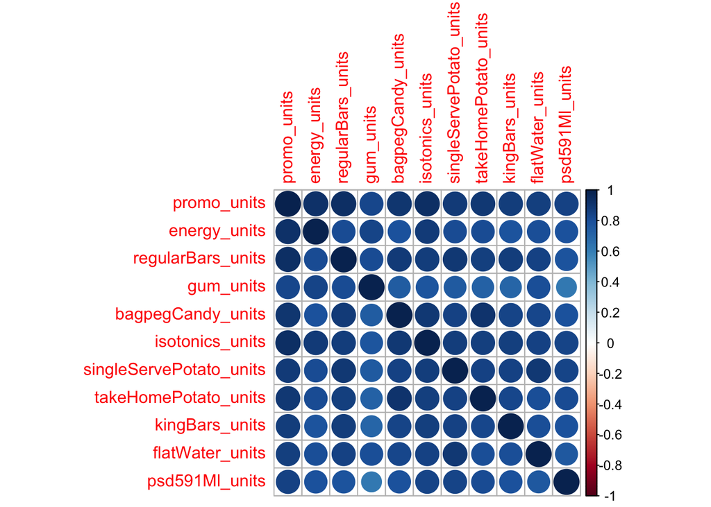

```r
Prod_Cat.cor = cor(Product_Categories, method = c("spearman"))
corrplot(as.matrix(Prod_Cat.cor))
```

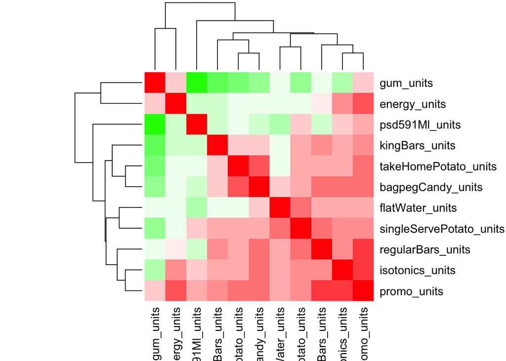

```r
palette = colorRampPalette(c("green", "white", "red")) (20)
heatmap(x = Prod_Cat.cor, col = palette, symm = TRUE)
```

From the Correlation Matrix the product categories that sell the least together are psd591MI_units & gum_units. While product categories bagpegCandy_units and takeHomePotato sell the most together.